# 데이터과학 방법론 산업적용 현재와 미래

통계학이 이론적으로 확립되기 이전부터 데이터를 활용하여 사회적 문제를 풀고 가치를 창출하고자하는 활동이 활발히 진행되었듯이, 데이터 과학을 산업현장에 적용하여 성공을 거둔 사례도 많고, 최근 유니콘으로 지칭되는 신생 스타트업 거의 모두 데이터 과학을 기업의 핵심역량으로 삼고 있다. 통계학과 차별화되는 데이터 과학 방법론의 핵심 내용을 응집하고 있는 데이터 과학 도구상자로 `Tidyverse`(타이디버스, 깔끔한 세상)를 들 수 있다. Tidyverse는 지구상 유일한 운영체제로 인정받고 있는 유닉스 운영체제의 철학을 계승하여 데이터 과학의 사실상 운영체제로 자리매김하고 있다. 거슬러 올라가 마이크로소프트의 개인용 컴퓨터 윈도우 운영체제에서 보았듯이 구글의 안드로이드 운영체제는 스마트폰을 하나의 산업으로 자리잡는데 커다란 기여를 했고, 더 나아가 안드로이드 생태계의 지속적인 성장도 담보하고 있고 있다. 데이터 경제를 굳건히 지탱하는 데이터 과학 운영체제인 `Tidyverse`는 데이터로부터 창출된 가치를 API로 만들어 더 큰 가치를 창출 시킬 수 있도록 학계는 물론이고 공공 및 산업계에도 데이터를 원자재로하는 선순환 경제성장모형을 만들어가는데 커다란 역할을 수행할 것으로 기대된다.

이광춘 https://www.facebook.com/groups/tidyverse/ (삼정 KPMG)https://home.kpmg/kr/ko/home.html  
2020-06-03

# 데이터 과학 산업규모

# 제2의 석유 데이터

[figure not shown]

과거 석유가 가장 중요한 자원으로 풍미하던 시절이 있었다. 하지만 이제 더이상 석유가 가장 중요한 자원이 아니라 이제는 누구라도 **데이터(Data)** 라고 말하는 것이 어색하지 않은 세상이 되었고 많은 분들이 이에 동의하고 있다. [1]

# 데이터 과학 제품/서비스 생산공장

## 석유

원유를 정제하게 되면

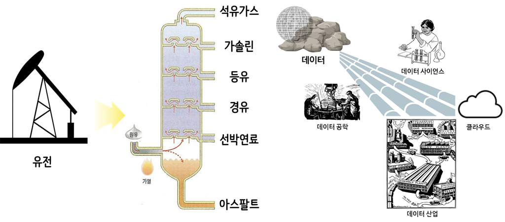

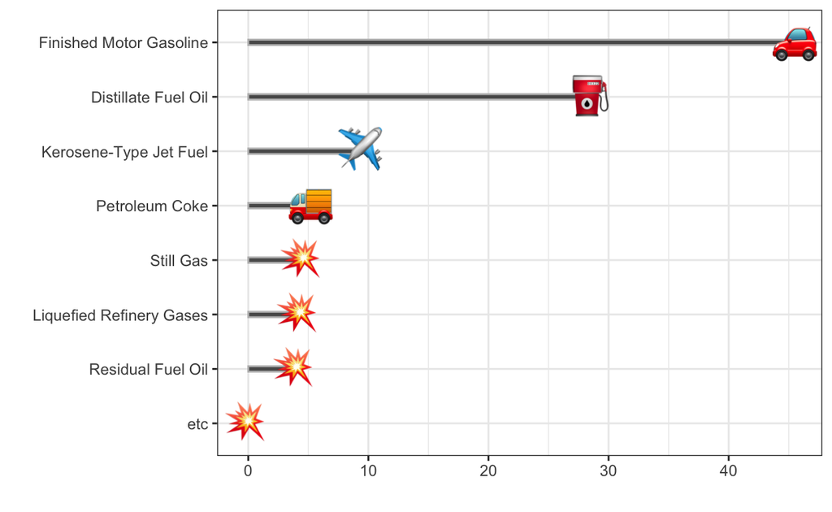

# 데이터 과학 경제: API Economy

# 데이터 과학 방법론: Tidyverse

# 마무리

1. Economist T. The world’s most valuable resource is no longer oil, but data. The Economist: New York, NY, USA. 2017.